# Análisis Aglomerativo I

Universidad Nacional de Colombia, Sede Medellín

Viernes, 25 de enero de 2019

## Lectura de las bases de datos

```r
# Lectura
ambient       <- read.csv2("ambientales.csv",enc="latin1",row.names=1)
peces         <- read.csv2("peces.csv",enc="latin1",row.names=1)
locs          <- read.csv2("localidades.csv",enc="latin1",row.names=1)
nomEspec      <- read.csv2("nombresdeespecies.csv",enc="latin1")
nomVarAmbient <- read.csv2("Nombresdevariablesambientales.csv",enc="latin1")

# Adecuación
# Quitar el sitio que no tiene ninguna especie
sumEsp  <- apply(peces,1,sum)
peces   <- peces[sumEsp!=0,]
ambient <- ambient[sumEsp!=0,]
locs    <- locs[sumEsp!=0,]
```

## Carga de paquetes requeridos

```r
# (vegan deberá ser cargado después de ade4 para evitar conflictos).
library(ade4)
library(vegan)
library(gclus)
library(cluster)
library(RColorBrewer)
```

## Métodos aglomerativos

Análisis de conglomerados jerárquico en la base de datos de abundancia de especies.

- Enlace simple: Simple Linkage Agglomerative Clustering.
  - Vecino más cercano.
  - Grupo más “amigables”. No siempre muestra grupos bien separados y definidos
  - Se usa para identificar gradientes en los datos.
- Enlace completo: Complete Linkage Agglomerative Clustering.
  - Vecino más lejano.
  - Un grupo adimite un miembro nuevo si todos están “de acuerdo” en su admisión. (requiere “unanimidad” de sus miembros)
  - Produce grupos más compactos, pequeños y diferenciados entre si.
  - Los grupos son más “esféricos” y de distribuciones multivariadas.
  - Identifica discontinuidades en los datos.

Algomeración de grupos mediante promedios o centroides.

- Promedios: Promedio de todas las distancias entre los miembros con el candidato.
- Centroide: Distancia del centro de masa del grupo con respecto al candidato.
- Peso o ponderación: Se tiene el número de miembros del grupo como una ponderación. Donde se tiene en cuentra el tamaño de grupo para el cálculo de la distancia al grupo (cluster).
  - Unweigthed: El peso el grupo es proporcional a su tamaño.
  - Weigthed: El peso es idéntico para cada grupo independiente de su tamaño.

|  | Promedios aritméticos | Agrupamiento por Centroide |
| --- | --- | --- |
| Pesos iguales | UPGMA | UPGMC |
| Num individuos | Unweighted Pair-Group | Unweighted Pair-Group Method |
|  | Method using aritmetic | using centroids |
|  | Average |  |
|  | “average” | “centroid” |
| Pesos distintos | WPGMA | WPGMC |
| Indep del num | Weighted Pair-Group Method | Weighted Pair-Group Method |
|  | using aritmetic Average | using centroid. |
|  | “mcquitty” | “median” |

Método de Ward utiliza el promedio de la suma de cuadrados de las distancias de todos los miembros del grupo. Se incorpora el miembro nuevo que minimice esta suma de cuadrados.

Algunas veces el UPGMC o el WPGMC lleva a dendrogramas con “reversazos”, esto hace difícil la interpretación de la conformación de grupos.

Se recomiendan en su orden de más recomendado a menos recomendado el siguiente orden UPGMA, WPGMA, WPGMC y UPGMC.

De manera numérica se tiene que el enlace se puede establecer como:

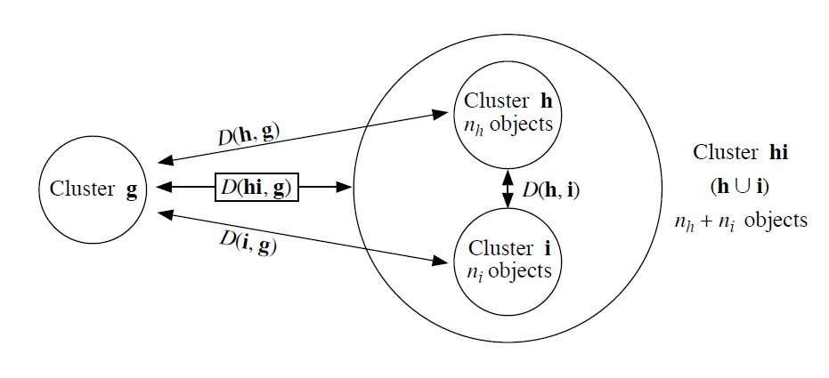

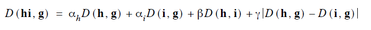

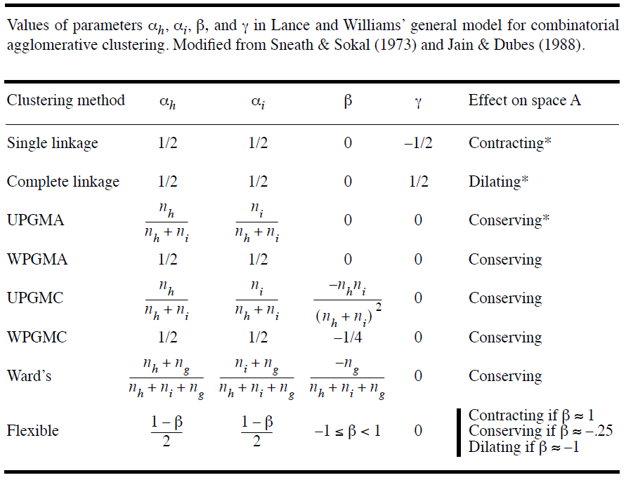

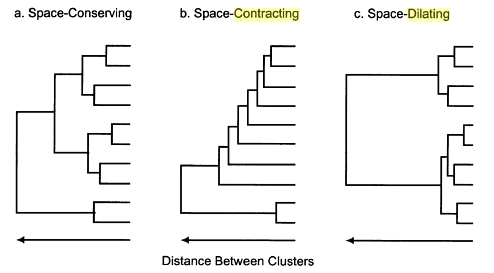

```r
# Cálculo de la matriz utilizando la distancia de Chord
# entre sitios, siguiente en enlace simple.
peces.norm <- decostand(peces, "normalize")
peces.ch <- vegdist(peces.norm, "euclidean")
```

```r
peces.ch.single <- hclust(peces.ch, method="single")
```

```r
# Estructura de los resultados de "hclust"
str(peces.ch.single)
```

```
## List of 7
##  $ merge      : int [1:28, 1:2] -20 -3 -2 -26 -25 -19 -28 6 -12 -16 ...
##  $ height     : num [1:28] 0.218 0.229 0.231 0.236 0.238 ...
##  $ order      : int [1:29] 8 5 1 18 29 19 20 21 28 25 ...
##  $ labels     : chr [1:29] "1" "2" "3" "4" ...
##  $ method     : chr "single"
##  $ call       : language hclust(d = peces.ch, method = "single")
##  $ dist.method: chr "euclidean"
##  - attr(*, "class")= chr "hclust"
```

```r
# Determinar el modo que realizó el agrupamiento teniendo en cuenta.
# la posición en la base de datos.
with(peces.ch.single,cbind(merge,height))
```

```
##                  height
##  [1,] -20 -21 0.2183057
##  [2,]  -3  -7 0.2292333
##  [3,]  -2   2 0.2309609
##  [4,] -26 -27 0.2357353
##  [5,] -25   4 0.2378549
##  [6,] -19   1 0.2641843
##  [7,] -28   5 0.2874361
##  [8,]   6   7 0.2896600
##  [9,] -12 -13 0.3024472
## [10,] -16 -17 0.3222605
## [11,]  -4  -6 0.3237064
## [12,] -29   8 0.3248500
## [13,]   3  11 0.3429386
## [14,] -10   9 0.3857583
## [15,] -11  13 0.3860668
## [16,]  14  15 0.3991963
## [17,]  -9  16 0.4598735
## [18,] -22 -23 0.4634492
## [19,] -14  17 0.4784253
## [20,] -18  12 0.4977122
## [21,] -15  19 0.5296564
## [22,]  10  21 0.5503781
## [23,]  20  22 0.5516516
## [24,] -24  18 0.5931939
## [25,]  23  24 0.6754943
## [26,]  -1  25 0.7653669
## [27,]  -5  26 0.8160106
## [28,]  -8  27 0.8814766
```

```r
peces[c(20,21),]
```

```
##    Cogo Satr Phph Neba Thth Teso Chna Chto Lele Lece Baba Spbi Gogo Eslu
## 21    0    0    1    1    0    0    2    2    2    2    4    2    5    3
## 22    0    0    0    1    0    0    3    2    3    4    5    1    5    3
##    Pefl Rham Legi Scer Cyca Titi Abbr Icme Acce Ruru Blbj Alal Anan
## 21    3    3    2    2    2    4    3    1    3    5    3    5    2
## 22    4    3    3    2    3    4    4    2    4    5    4    5    2
```

```r
peces.norm[c(20,21),]
```

```
##    Cogo Satr       Phph       Neba Thth Teso      Chna      Chto      Lele
## 21    0    0 0.07071068 0.07071068    0    0 0.1414214 0.1414214 0.1414214
## 22    0    0 0.00000000 0.06108472    0    0 0.1832542 0.1221694 0.1832542
##         Lece      Baba       Spbi      Gogo      Eslu      Pefl      Rham
## 21 0.1414214 0.2828427 0.14142136 0.3535534 0.2121320 0.2121320 0.2121320
## 22 0.2443389 0.3054236 0.06108472 0.3054236 0.1832542 0.2443389 0.1832542
##         Legi      Scer      Cyca      Titi      Abbr       Icme      Acce
## 21 0.1414214 0.1414214 0.1414214 0.2828427 0.2121320 0.07071068 0.2121320
## 22 0.1832542 0.1221694 0.1832542 0.2443389 0.2443389 0.12216944 0.2443389
##         Ruru      Blbj      Alal      Anan
## 21 0.3535534 0.2121320 0.3535534 0.1414214
## 22 0.3054236 0.2443389 0.3054236 0.1221694
```

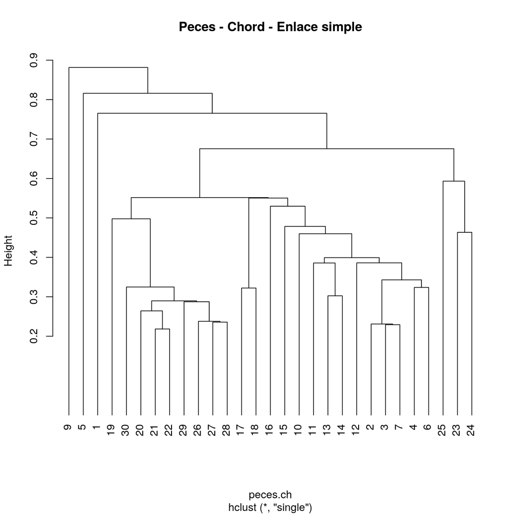

```r
# Gráfica del dendograma usando las opciones por omisión.
plot(peces.ch.single, main="Peces - Chord - Enlace simple", hang = -1)
```

```r
# Ordenación con respecto al gradiente de distancia a la desembocadura.
ambient2 <- ambient
ambient2$pos <- 1:nrow(ambient)
ambient2 <- ambient2[peces.ch.single$order, ]
ambient2$consec <- 1:nrow(ambient2)
```

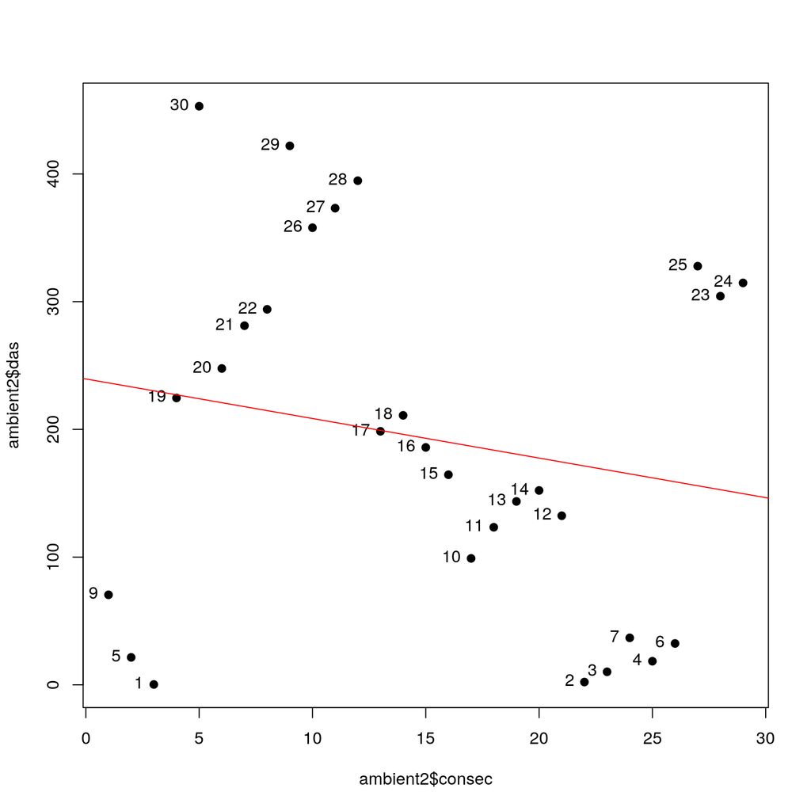

```r
# Gráfica que muestra posibles gradientes determinados por la agrupación
plot(ambient2$consec, ambient2$das, pch = 19)
text(ambient2$consec, ambient2$das,
     labels = row.names(ambient2),
     pos = 2)
abline(coef=coef(lm(ambient2$das ~ ambient2$consec)),col="red")
```

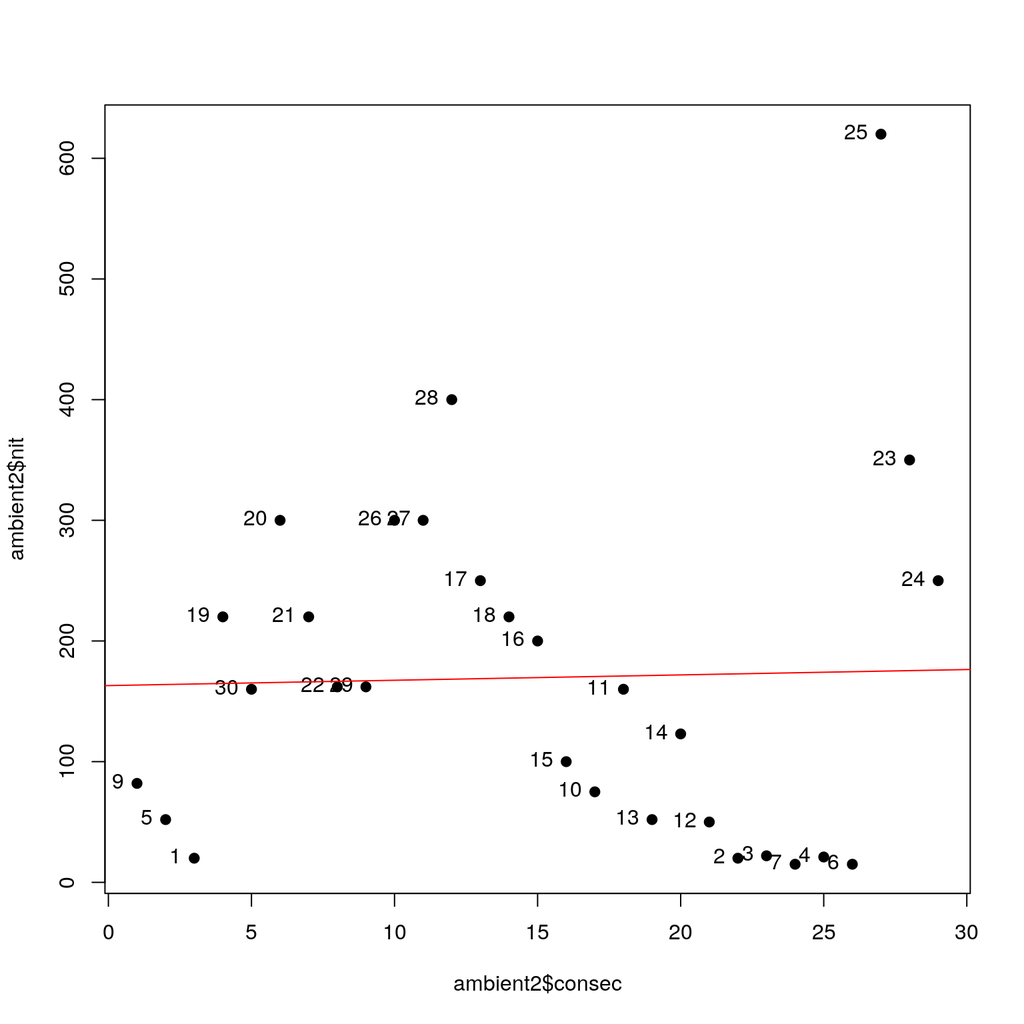

```r
# Gráfica que muestra posibles gradientes determinados por la agrupación
plot(ambient2$consec, ambient2$nit, pch = 19)
text(ambient2$consec, ambient2$nit,
     labels = row.names(ambient2),
     pos = 2)
abline(coef=coef(lm(ambient2$nit ~ ambient2$consec)),col="red")
```

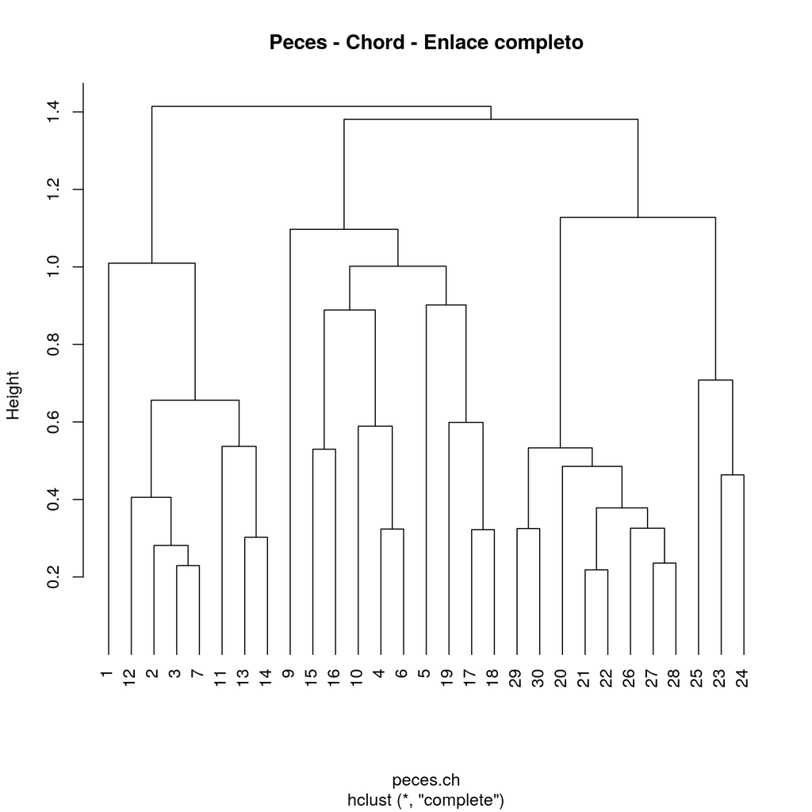

```r
# Cálculo utilizando el enlace completo
peces.ch.complete <- hclust(peces.ch, method="complete")
plot(peces.ch.complete,main="Peces - Chord - Enlace completo", hang = -1)
```

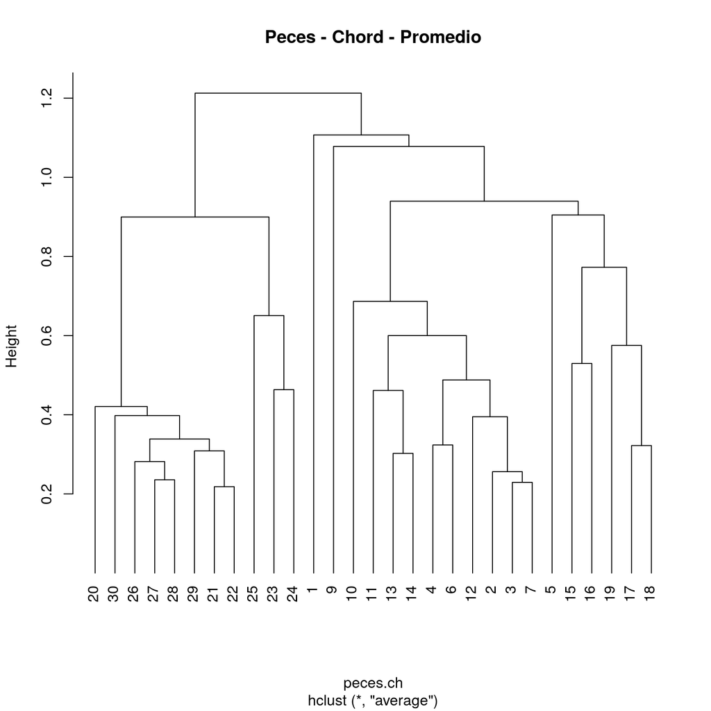

```r
# Cálculo mediante UPGMA
peces.ch.UPGMA <- hclust(peces.ch, method="average")
plot(peces.ch.UPGMA,main="Peces - Chord - Promedio", hang =  -1)
```

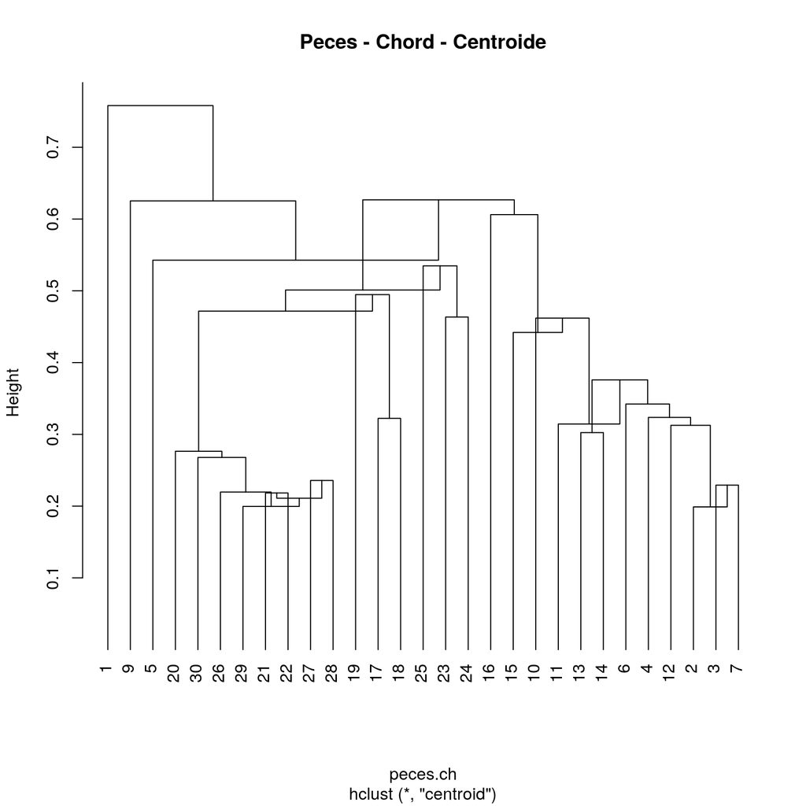

```r
# Cálculo mediante UPGMC
peces.ch.centroid <- hclust(peces.ch, method="centroid")
plot(peces.ch.centroid,main="Peces - Chord - Centroide", hang = -1)
```

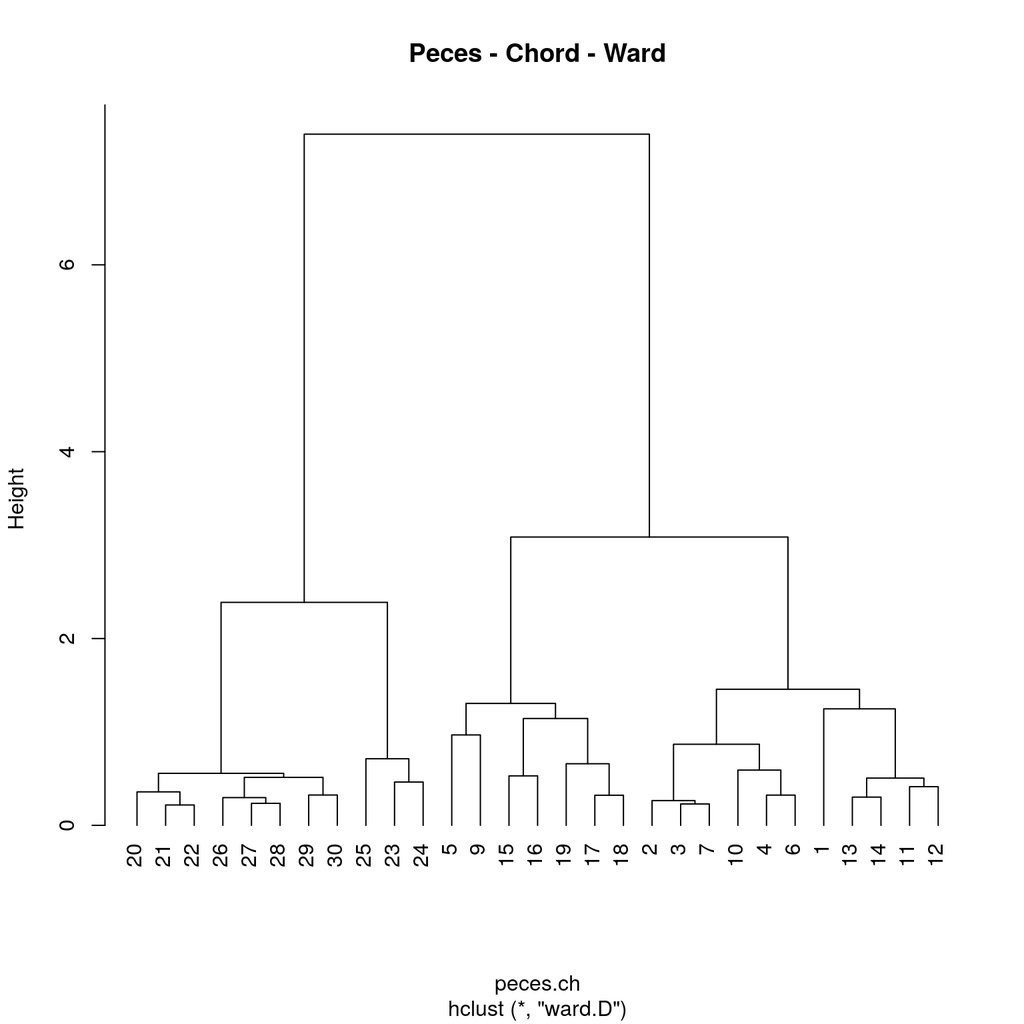

```r
# Utilizando el métod de Ward
peces.ch.ward <- hclust(peces.ch, method="ward.D")
plot(peces.ch.ward,main="Peces - Chord - Ward", hang = -1)
```

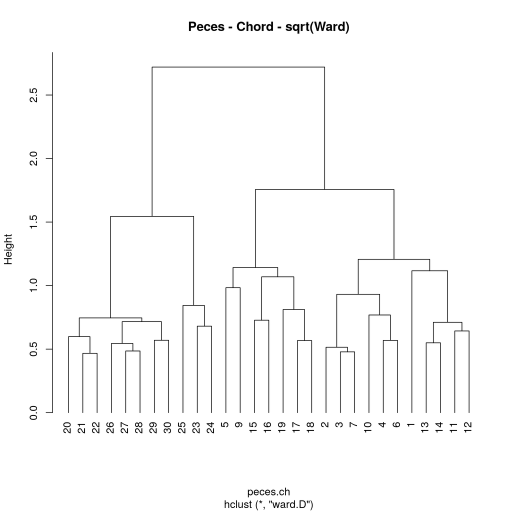

```r
# Transformación raiz cuadrada de la altura
peces.ch.ward$height <- sqrt(peces.ch.ward$height)
plot(peces.ch.ward,main="Peces - Chord - sqrt(Ward)", hang = -1)
```